# Founders Novelty Data: Heritability and Plotting

Michael C. Saul (michael.saul [at] jax.org)

# 1 Background

## 1.1 Motivation

### 1.1.1 Purpose of analysis

This analysis is performed to process the novelty data and calculate:

1. Heritability
2. Strain-by-sex means and standard errors for plotting

**These data were collected by the CSNA behavioral phenotyping core. Ultimate authorship for these data will need to be discussed with Leona Gagnon.** The preprocessing notebook `novelty_import_preprocess.Rmd` was used to filter the data to only those data requiring reporting.

# 2 Analysis

## 2.1 Setup

### 2.1.1 Working directory

All chunks will run in the working folder for this experiment.

```r
script_root_dir = "~/Downloads/founders_heritability/"
knitr::opts_knit$set(root.dir = script_root_dir)
```

Getting current date

```r
current_date = format(Sys.time(),"%Y-%m-%d")
```

### 2.1.2 R libraries

Calling R libraries necessary for this analysis.

```r
library("tidyverse")
```

```r
library("lubridate")
library("cowplot")
library("MASS")
library("ggbeeswarm")
```

## 2.2 Importing data

Getting data from the filtering script.

```r
novelty_data = readRDS(paste(script_root_dir, "data/novelty_data_preprocessed_2019-09-12.RDS", sep = ""))
```

Displaying raw data.

```r
novelty_data
```

|  | Mouse_ID | Strain | Sex | OFA_test_year | OFA_test_month | OFA_test_day | OFA_tester | OFA_pct_dist_center | LD_test_year | LD_test_month | LD_test_day | LD_tester | LD_total_transitions | HB_test_year | HB_test_month | HB_test_day | HB_tester | HB_Total_Entries | NPP_test_year | NPP_test_month | NPP_test_day | NPP_ZoneTime_GreyWhiteBlack_Total |
| --- | --- | --- | --- | --- | --- | --- | --- | --- | --- | --- | --- | --- | --- | --- | --- | --- | --- | --- | --- | --- | --- | --- |
| 479 | 479 | NOD/ShiLtJ | F | 2017 | 6 | 12 | MRL | 0.515569834 | 2017 | 6 | 13 | MRL | 115 | 2017 | 6 | 14 | MRL | 6 | 2017 | 6 | 15 | 53.014167 |
| 480 | 480 | NOD/ShiLtJ | F | NA | NA | NA | NA | NA | 2017 | 6 | 13 | MRL | 50 | 2017 | 6 | 14 | MRL | 3 | 2017 | 6 | 15 | 65.287500 |
| 481 | 481 | NOD/ShiLtJ | F | 2017 | 6 | 12 | MRL | 0.600124878 | 2017 | 6 | 13 | MRL | 92 | 2017 | 6 | 14 | MRL | 27 | 2017 | 6 | 15 | 87.415833 |
| 482 | 482 | NOD/ShiLtJ | F | 2017 | 6 | 12 | MRL | 0.729958451 | 2017 | 6 | 13 | MRL | 169 | 2017 | 6 | 14 | MRL | 19 | 2017 | 6 | 15 | 5.070833 |
| 489 | 489 | A/J | F | NA | NA | NA | NA | NA | 2017 | 6 | 13 | MRL | 24 | 2017 | 6 | 14 | MRL | 2 | 2017 | 6 | 15 | 40.657500 |
| 490 | 490 | A/J | F | 2017 | 6 | 12 | MRL | 0.069335720 | 2017 | 6 | 13 | MRL | 45 | 2017 | 6 | 14 | MRL | 10 | 2017 | 6 | 15 | 52.979167 |
| 491 | 491 | A/J | F | 2017 | 6 | 12 | MRL | 0.029193179 | 2017 | 6 | 13 | MRL | 12 | 2017 | 6 | 14 | MRL | 2 | 2017 | 6 | 15 | 27.136667 |
| 502 | 502 | A/J | M | NA | NA | NA | NA | NA | 2017 | 6 | 13 | MRL | 20 | 2017 | 6 | 14 | MRL | 4 | 2017 | 6 | 15 | 21.060000 |
| 503 | 503 | A/J | M | 2017 | 6 | 12 | MRL | 0.063257563 | 2017 | 6 | 13 | MRL | 29 | 2017 | 6 | 14 | MRL | 37 | 2017 | 6 | 15 | 30.477500 |
| 504 | 504 | A/J | M | 2017 | 6 | 12 | MRL | 0.017052191 | 2017 | 6 | 13 | MRL | 2 | 2017 | 6 | 14 | MRL | 5 | 2017 | 6 | 15 | 32.729167 |

[output cut: 773 more lines]

Getting founders strain key

```r
founders_key = readRDS("~/Desktop/cc_do_founders_key.RDS")
row.names(founders_key) = founders_key$strain
```

### 2.3.1 Fitting ANOVA model for Open Field data

Looking at the residuals of the simplest model first.

```r
OFA_data = novelty_data %>%
  dplyr::select(Mouse_ID, Strain, Sex, OFA_tester, OFA_pct_dist_center) %>%
  filter(!is.na(OFA_pct_dist_center))
anova(lm(OFA_pct_dist_center ~ OFA_tester + Strain + Sex + Strain:Sex, data = OFA_data))
```

|  | Df | Sum Sq | Mean Sq | F value | Pr(>F) |
| --- | --- | --- | --- | --- | --- |
| OFA_tester | 4 | 0.43609338 | 0.10902335 | 7.2937737 | 9.373929e-06 |
| Strain | 7 | 11.02870030 | 1.57552861 | 105.4044813 | 2.659972e-104 |
| Sex | 1 | 0.00906256 | 0.00906256 | 0.6062946 | 4.364557e-01 |
| Strain:Sex | 7 | 0.21824798 | 0.03117828 | 2.0858591 | 4.297015e-02 |
| Residuals | 684 | 10.22405841 | 0.01494745 | NA | NA |

Tester is a significant effect in the naive model. However, genetic background (`Strain`) remains the strongest effect. Testing the residuals for the simplest model with only the `Strain` factor in it.

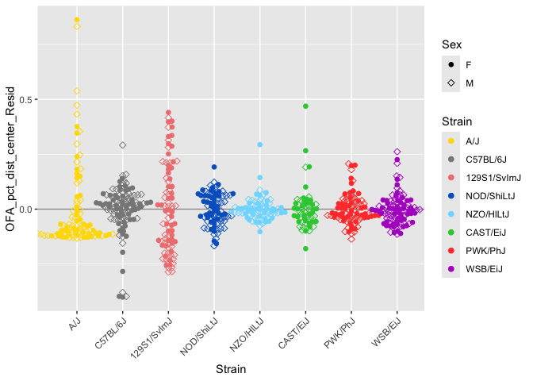

```r
OFA_resid = OFA_data
OFA_resid$OFA_pct_dist_center_Resid = resid(lm(OFA_pct_dist_center ~ Strain, data = OFA_resid))
OFA_resid$Strain = factor(OFA_resid$Strain,
                          levels = founders_key$strain,
                          ordered = TRUE)

ggplot(data = OFA_resid, aes(x = Strain, y = OFA_pct_dist_center_Resid, color = Strain, shape = Sex)) +
  geom_hline(yintercept = 0, col = "#999999") +
  geom_beeswarm(size = 2) +
  scale_color_manual(values = founders_key$collaborative_cross_color_broman) +
  theme(axis.text.x = element_text(angle = 45, hjust = 1)) +
  scale_shape_manual(values = c(16,23))
```

```r
AICs = c()
AICs["AIC_inter"] = AIC(lm(OFA_pct_dist_center ~ OFA_tester + Strain + Sex + Strain:Sex, data = OFA_data))
AICs["AIC_nointer"] = AIC(lm(OFA_pct_dist_center ~ OFA_tester + Strain + Sex, data = OFA_data))
AICs["AIC_nosex"] = AIC(lm(OFA_pct_dist_center ~ OFA_tester + Strain, data = OFA_data))
AICs["AIC_notester"] = AIC(lm(OFA_pct_dist_center ~ Strain, data = OFA_data))
AICs["AIC_nostrain"] = AIC(lm(OFA_pct_dist_center ~ OFA_tester, data = OFA_data))

AICs
```

```
##    AIC_inter  AIC_nointer    AIC_nosex AIC_notester AIC_nostrain
##    -939.4870    -938.6172    -940.0065    -943.8331    -446.8502
```

```r
BICs = c()
BICs["BIC_inter"] = BIC(lm(OFA_pct_dist_center ~ OFA_tester + Strain + Sex + Strain:Sex, data = OFA_data))
BICs["BIC_nointer"] = BIC(lm(OFA_pct_dist_center ~ OFA_tester + Strain + Sex, data = OFA_data))
BICs["BIC_nosex"] = BIC(lm(OFA_pct_dist_center ~ OFA_tester + Strain, data = OFA_data))
BICs["BIC_notester"] = BIC(lm(OFA_pct_dist_center ~ Strain, data = OFA_data))
BICs["BIC_nostrain"] = BIC(lm(OFA_pct_dist_center ~ OFA_tester, data = OFA_data))

BICs
```

```
##    BIC_inter  BIC_nointer    BIC_nosex BIC_notester BIC_nostrain
##    -843.7947    -874.8223    -880.7684    -902.8221    -419.5095
```

The best model for heritability according to both AIC and BIC includes only the strain effect. The residuals plot shows that this model has an okay fit. Showing ANOVA table for this model.

```r
anova(lm(OFA_pct_dist_center ~ Strain, data = OFA_data))
```

|  | Df | Sum Sq | Mean Sq | F value | Pr(>F) |
| --- | --- | --- | --- | --- | --- |
| Strain | 7 | 11.40265 | 1.62895039 | 107.8374 | 1.298519e-106 |
| Residuals | 696 | 10.51351 | 0.01510562 | NA | NA |

```r
anova(lm(OFA_pct_dist_center ~ Strain, data = OFA_data))$`Pr(>F)`[1]
```

```
## [1] 1.298519e-106
```

This will be used for downstream heritability calculations.

### 2.3.2 Calculating heritability for open field data

Calculating heritability using the ANOVA table from the best fitting model. Using the following equation:

$h^2=\displaystyle{{MS_{strain}-MS_{resid}}\over{MS_{strain} + (n_{mean} - 1) * MS_{resid}}}$

where $MS_{strain}$ is the mean square of the strain differences, $MS_{resid}$ is the mean square of the residuals, and $n_{mean}$ is the mean sample size of a strain.

```r
h2_strainanova <- function(msgenetics, mserror, n) {
  return((msgenetics - mserror) / (msgenetics + (n - 1) * mserror))
}

mean_n = nrow(OFA_data) / length(unique(OFA_data$Strain))
anova_OFA = anova(lm(OFA_pct_dist_center ~ Strain, data = OFA_data))
anova_OFA_df = as.data.frame(anova_OFA)
h2_OFA = h2_strainanova(anova_OFA_df["Strain","Mean Sq"],
                        anova_OFA_df["Residuals","Mean Sq"],
                        mean_n)
h2_OFA
```

```
## [1] 0.5483413
```

This $H^2$ calculation of 0.55 is better than previous estimates.

### 2.3.3 Plotting strain x sex means for open field proportion of time in center

Plotting the strain:sex information for these data.

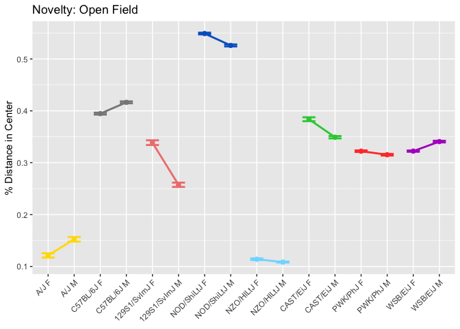

```r
OFA_plotting_summary = OFA_data %>%
  group_by(Strain, Sex) %>%
  summarize(Strain_Sex_mean = mean(OFA_pct_dist_center, na.rm = TRUE),
            Strain_Sex_sem = sd(OFA_pct_dist_center, na.rm = TRUE) / length(which(!is.na(OFA_pct_dist_center)))) %>%
  mutate(Strain_Sex = paste(Strain, gsub("^([MF]).*$", "\\1", Sex), sep = " "),
         Strain_Sex_ul = Strain_Sex_mean + Strain_Sex_sem,
         Strain_Sex_ll = Strain_Sex_mean - Strain_Sex_sem)
OFA_plotting_summary = as.data.frame(OFA_plotting_summary)
OFA_plotting_summary$Strain_Sex = factor(OFA_plotting_summary$Strain_Sex,
                                         levels = paste(rep(founders_key$strain, each = 2), rep(c(" F", " M"), times = 8), sep = ""),
                                         ordered = TRUE)
OFA_plotting_summary$Strain = factor(OFA_plotting_summary$Strain,
                                     levels = founders_key$strain,
                                     ordered = TRUE)

OFA_pct_dist_center_strain_sex_plot = ggplot(data = OFA_plotting_summary, aes(x = Strain_Sex, y = Strain_Sex_mean, color = Strain, group = Strain)) +
  geom_line(size = 1) +
  geom_point(size = 2) +
  geom_errorbar(aes(ymin = Strain_Sex_ll, ymax = Strain_Sex_ul), width = 0.5, size = 1) +
  scale_color_manual(values = founders_key$collaborative_cross_color_broman) +
  theme(axis.text.x = element_text(angle = 45, hjust = 1), legend.position="none") +
  xlab(NULL) +
  ylab("% Distance in Center") +
  ggtitle("Novelty: Open Field")
OFA_pct_dist_center_strain_sex_plot
```

Saving plot

```r
saveRDS(OFA_pct_dist_center_strain_sex_plot, "./output/founders_OFA_pcenter_strain_sex_plot.RDS")
```

### 2.3.4 Fitting ANOVA model for Light-Dark data

Starting with an ANOVA with all factors.

```r
LD_data = novelty_data %>%
  dplyr::select(Mouse_ID, Strain, Sex, LD_tester, LD_total_transitions) %>%
  filter(!is.na(LD_total_transitions))
anova(lm(LD_total_transitions ~ LD_tester + Strain + Sex + Strain:Sex, data = LD_data))
```

|  | Df | Sum Sq | Mean Sq | F value | Pr(>F) |
| --- | --- | --- | --- | --- | --- |
| LD_tester | 5 | 175711.921 | 35142.384 | 6.9240051 | 2.560200e-06 |
| Strain | 7 | 959440.778 | 137062.968 | 27.0051309 | 8.874523e-33 |
| Sex | 1 | 2611.082 | 2611.082 | 0.5144542 | 4.734633e-01 |
| Strain:Sex | 7 | 48880.626 | 6982.947 | 1.3758303 | 2.125011e-01 |
| Residuals | 680 | 3451300.373 | 5075.442 | NA | NA |

Tester is a significant factor here as well. Again, `Strain` is highly significant. Looking at the residuals of the simplest model first.

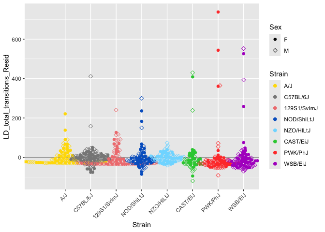

```r
LD_data = novelty_data %>%
  dplyr::select(Mouse_ID, Strain, Sex, LD_tester, LD_total_transitions) %>%
  filter(!is.na(LD_total_transitions))
LD_resid = LD_data
LD_resid$LD_total_transitions_Resid = resid(lm(LD_total_transitions ~ Strain, data = LD_resid))
LD_resid$Strain = factor(LD_resid$Strain,
                         levels = founders_key$strain,
                         ordered = TRUE)

ggplot(data = LD_resid, aes(x = Strain, y = LD_total_transitions_Resid, color = Strain, shape = Sex)) +
  geom_hline(yintercept = 0, col = "#999999") +
  geom_beeswarm(size = 2) +
  scale_color_manual(values = founders_key$collaborative_cross_color_broman) +
  theme(axis.text.x = element_text(angle = 45, hjust = 1)) +
  scale_shape_manual(values = c(16,23))
```

These residuals are skewed. Evaluating transforms using Box-Cox.

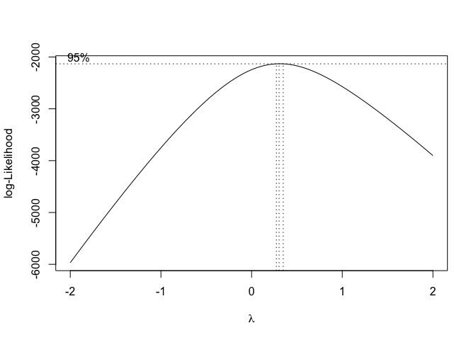

```r
boxcox(lm(LD_total_transitions ~ Strain, data = LD_resid))
```

The Box-Cox log-likelihood appears centered at 1/3, indicating that a cube-root transformation may be merited.

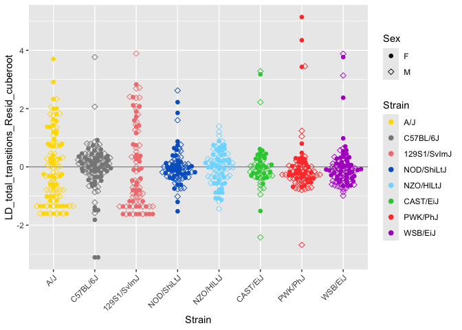

```r
LD_resid$LD_total_transitions_cuberoot = LD_resid$LD_total_transitions ^ (1/3)
LD_resid$LD_total_transitions_Resid_cuberoot = resid(lm(LD_total_transitions_cuberoot ~ Strain, data = LD_resid))

ggplot(data = LD_resid, aes(x = Strain, y = LD_total_transitions_Resid_cuberoot, color = Strain, shape = Sex)) +
  geom_hline(yintercept = 0, col = "#999999") +
  geom_beeswarm(size = 2) +
  scale_color_manual(values = founders_key$collaborative_cross_color_broman) +
  theme(axis.text.x = element_text(angle = 45, hjust = 1)) +
  scale_shape_manual(values = c(16,23))
```

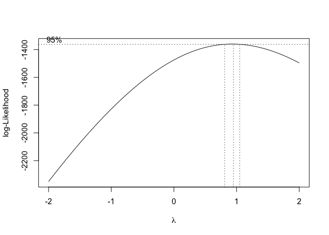

```r
boxcox(lm(LD_total_transitions_cuberoot ~ Strain, data = LD_resid))
```

The cube-root transform appears to perform well. Testing a number of different models for the light-dark data.

```r
AICs = c()
AICs["AIC_inter"] = AIC(lm(LD_total_transitions ^ (1/3) ~ LD_tester + Strain + Sex + Strain:Sex, data = LD_data))
AICs["AIC_nointer"] = AIC(lm(LD_total_transitions ^ (1/3) ~ LD_tester + Strain + Sex, data = LD_data))
AICs["AIC_nosex"] = AIC(lm(LD_total_transitions ^ (1/3) ~ LD_tester + Strain, data = LD_data))
AICs["AIC_notester"] = AIC(lm(LD_total_transitions ^ (1/3) ~ Strain, data = LD_data))
AICs["AIC_nostrain"] = AIC(lm(LD_total_transitions ^ (1/3) ~ LD_tester, data = LD_data))

AICs
```

```
##    AIC_inter  AIC_nointer    AIC_nosex AIC_notester AIC_nostrain
##     1956.012     1952.490     1950.642     1944.211     2374.931
```

```r
BICs = c()
BICs["BIC_inter"] = BIC(lm(LD_total_transitions ^ (1/3) ~ LD_tester + Strain + Sex + Strain:Sex, data = LD_data))
BICs["BIC_nointer"] = BIC(lm(LD_total_transitions ^ (1/3) ~ LD_tester + Strain + Sex, data = LD_data))
BICs["BIC_nosex"] = BIC(lm(LD_total_transitions ^ (1/3) ~ LD_tester + Strain, data = LD_data))
BICs["BIC_notester"] = BIC(lm(LD_total_transitions ^ (1/3) ~ Strain, data = LD_data))
BICs["BIC_nostrain"] = BIC(lm(LD_total_transitions ^ (1/3) ~ LD_tester, data = LD_data))

BICs
```

```
##    BIC_inter  BIC_nointer    BIC_nosex BIC_notester BIC_nostrain
##     2056.167     2020.778     2014.377     1985.183     2406.799
```

The AIC and BIC both indicate that the best model includes only strain. Showing the ANOVA table for this model.

```r
anova(lm(LD_total_transitions ^ (1/3) ~ Strain, data = LD_data))
```

|  | Df | Sum Sq | Mean Sq | F value | Pr(>F) |
| --- | --- | --- | --- | --- | --- |
| Strain | 7 | 583.2961 | 83.3280089 | 90.14142 | 4.101563e-93 |
| Residuals | 693 | 640.6190 | 0.9244142 | NA | NA |

```r
anova(lm(LD_total_transitions ^ (1/3) ~ Strain, data = LD_data))$`Pr(>F)`[1]
```

```
## [1] 4.101563e-93
```

### 2.3.5 Calculating heritability for light-dark transitions data

Calculating heritability using the ANOVA table from the best fitting model. Using the following equation:

$h^2=\displaystyle{{MS_{strain}-MS_{resid}}\over{MS_{strain} + (n_{mean} - 1) * MS_{resid}}}$

where $MS_{strain}$ is the mean square of the strain differences, $MS_{resid}$ is the mean square of the residuals, and $n_{mean}$ is the mean sample size of a strain.

```r
mean_n = nrow(LD_data) / length(unique(LD_data$Strain))
anova_LD = anova(lm(LD_total_transitions ^ (1/3) ~ Strain, data = LD_data))
anova_LD_df = as.data.frame(anova_LD)

h2_LD = h2_strainanova(anova_LD_df["Strain","Mean Sq"],
                       anova_LD_df["Residuals","Mean Sq"],
                       mean_n)
h2_LD
```

```
## [1] 0.5042893
```

This $H^2$ calculation of 0.5 is also better than previous estimates.

### 2.3.6 Plotting strain x sex means for transitions between light and dark.

Plotting the strain:sex information for these data.

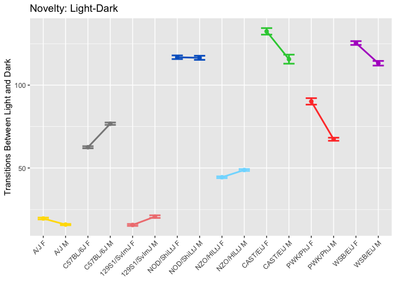

```r
LD_plotting_summary = LD_data %>%
  group_by(Strain, Sex) %>%
  summarize(Strain_Sex_mean = mean(LD_total_transitions ^ (1/3), na.rm = TRUE),
            Strain_Sex_sem = sd(LD_total_transitions ^ (1/3), na.rm = TRUE) / length(which(!is.na(LD_total_transitions ^ (1/3))))) %>%
  mutate(Strain_Sex = paste(Strain, gsub("^([MF]).*$", "\\1", Sex), sep = " "),
         Strain_Sex_backtrans_mean = Strain_Sex_mean ^ 3,
         Strain_Sex_ul = (Strain_Sex_mean + Strain_Sex_sem) ^ 3,
         Strain_Sex_ll = (Strain_Sex_mean - Strain_Sex_sem) ^ 3)
LD_plotting_summary = as.data.frame(LD_plotting_summary)
LD_plotting_summary$Strain_Sex = factor(LD_plotting_summary$Strain_Sex,
                                        levels = paste(rep(founders_key$strain, each = 2), rep(c(" F", " M"), times = 8), sep = ""),
                                        ordered = TRUE)
LD_plotting_summary$Strain = factor(LD_plotting_summary$Strain,
                                     levels = founders_key$strain,
                                     ordered = TRUE)

LD_transitions_plot = ggplot(data = LD_plotting_summary, aes(x = Strain_Sex, y = Strain_Sex_backtrans_mean, color = Strain, group = Strain)) +
  geom_line(size = 1) +
  geom_point(size = 2) +
  geom_errorbar(aes(ymin = Strain_Sex_ll, ymax = Strain_Sex_ul), width = 0.5, size = 1) +
  scale_color_manual(values = founders_key$collaborative_cross_color_broman) +
  theme(axis.text.x = element_text(angle = 45, hjust = 1), legend.position="none") +
  xlab(NULL) +
  ylab("Transitions Between Light and Dark") +
  ggtitle("Novelty: Light-Dark")

LD_transitions_plot
```

Saving plot

```r
saveRDS(LD_transitions_plot, "./output/founders_LD_transitions_strain_sex_plot.RDS")
```

### 2.3.7 Fitting ANOVA model for Hole Board data

Fitting the ANOVA with all effects first.

```r
HB_data = novelty_data %>%
  dplyr::select(Mouse_ID, Strain, Sex, HB_tester, HB_Total_Entries) %>%
  filter(!is.na(HB_Total_Entries))
anova(lm(HB_Total_Entries ~ HB_tester + Strain + Sex + Strain:Sex, data = HB_data))
```

|  | Df | Sum Sq | Mean Sq | F value | Pr(>F) |
| --- | --- | --- | --- | --- | --- |
| HB_tester | 5 | 32898.542 | 6579.7084 | 9.624731 | 7.536679e-09 |
| Strain | 7 | 247800.290 | 35400.0414 | 51.782823 | 1.293818e-57 |
| Sex | 1 | 7306.046 | 7306.0456 | 10.687210 | 1.140815e-03 |
| Strain:Sex | 7 | 13126.338 | 1875.1911 | 2.743011 | 8.257821e-03 |
| Residuals | 597 | 408124.229 | 683.6252 | NA | NA |

All factors are significant including the `Strain:Sex` interaction. Looking at the residuals of this model first.

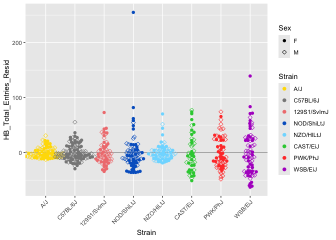

```r
HB_resid = HB_data
HB_resid$HB_Total_Entries_Resid = resid(lm(HB_Total_Entries ~ HB_tester + Strain + Sex + Strain:Sex, data = HB_resid))
HB_resid$Strain = factor(HB_resid$Strain,
                         levels = founders_key$strain,
                         ordered = TRUE)

ggplot(data = HB_resid, aes(x = Strain, y = HB_Total_Entries_Resid, color = Strain, shape = Sex)) +
  geom_hline(yintercept = 0, col = "#999999") +
  geom_beeswarm(size = 2) +
  scale_color_manual(values = founders_key$collaborative_cross_color_broman) +
  theme(axis.text.x = element_text(angle = 45, hjust = 1)) +
  scale_shape_manual(values = c(16,23))
```

These residuals show some heteroscedasticity, but it appears to be within the tolerance of linear models. Using the untransformed data to select model using AIC and BIC.

```r
AICs = c()
AICs["AIC_inter"] = AIC(lm(HB_Total_Entries ~ HB_tester + Strain + Sex + Strain:Sex, data = HB_data))
AICs["AIC_nointer"] = AIC(lm(HB_Total_Entries ~ HB_tester + Strain + Sex, data = HB_data))
AICs["AIC_nosex"] = AIC(lm(HB_Total_Entries ~ HB_tester + Strain, data = HB_data))
AICs["AIC_notester"] = AIC(lm(HB_Total_Entries ~ Strain, data = HB_data))
AICs["AIC_nostrain"] = AIC(lm(HB_Total_Entries ~ HB_tester, data = HB_data))

AICs
```

```
##    AIC_inter  AIC_nointer    AIC_nosex AIC_notester AIC_nostrain
##     5810.382     5815.946     5824.572     5821.654     6092.564
```

```r
BICs = c()
BICs["BIC_inter"] = BIC(lm(HB_Total_Entries ~ HB_tester + Strain + Sex + Strain:Sex, data = HB_data))
BICs["BIC_nointer"] = BIC(lm(HB_Total_Entries ~ HB_tester + Strain + Sex, data = HB_data))
BICs["BIC_nosex"] = BIC(lm(HB_Total_Entries ~ HB_tester + Strain, data = HB_data))
BICs["BIC_notester"] = BIC(lm(HB_Total_Entries ~ Strain, data = HB_data))
BICs["BIC_nostrain"] = BIC(lm(HB_Total_Entries ~ HB_tester, data = HB_data))

BICs
```

```
##    BIC_inter  BIC_nointer    BIC_nosex BIC_notester BIC_nostrain
##     5907.765     5882.343     5886.543     5861.492     6123.550
```

```r
anova(lm(HB_Total_Entries ~ Strain, data = HB_data))
```

|  | Df | Sum Sq | Mean Sq | F value | Pr(>F) |
| --- | --- | --- | --- | --- | --- |
| Strain | 7 | 275759.8 | 39394.2527 | 55.43422 | 2.889521e-61 |
| Residuals | 610 | 433495.7 | 710.6486 | NA | NA |

```r
anova(lm(HB_Total_Entries ~ Strain, data = HB_data))$`Pr(>F)`[1]
```

```
## [1] 2.889521e-61
```

### 2.3.8 Calculating heritability for hole board total entries data

Calculating heritability using the ANOVA table from the best fitting model. Using the following equation:

$h^2=\displaystyle{{MS_{strain}-MS_{resid}}\over{MS_{strain} + (n_{mean} - 1) * MS_{resid}}}$

where $MS_{strain}$ is the mean square of the strain differences, $MS_{resid}$ is the mean square of the residuals, and $n_{mean}$ is the mean sample size of a strain.

```r
mean_n = nrow(HB_data) / length(unique(HB_data$Strain))
anova_HB = anova(lm(HB_Total_Entries ~ Strain, data = HB_data))
anova_HB_df = as.data.frame(anova_HB)
h2_HB = h2_strainanova(anova_HB_df["Strain","Mean Sq"],
                       anova_HB_df["Residuals","Mean Sq"],
                       mean_n)
h2_HB
```

```
## [1] 0.4133693
```

This $H^2$ calculation of 0.41 is also better than previous estimates, which were below 0.4.

### 2.3.9 Plotting strain x sex means for hole board total entries

Plotting the strain:sex information for these data.

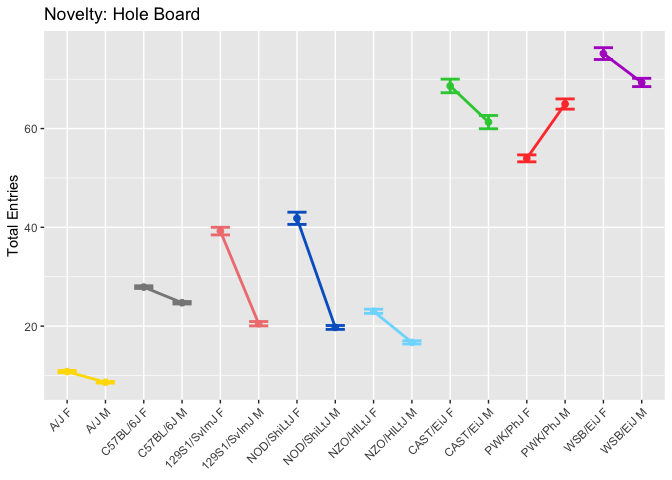

```r
HB_plotting_summary = HB_data %>%
  group_by(Strain, Sex) %>%
  summarize(Strain_Sex_mean = mean(HB_Total_Entries, na.rm = TRUE),
            Strain_Sex_sem = sd(HB_Total_Entries, na.rm = TRUE) / length(which(!is.na(HB_Total_Entries)))) %>%
  mutate(Strain_Sex = paste(Strain, gsub("^([MF]).*$", "\\1", Sex), sep = " "),
         Strain_Sex_ul = Strain_Sex_mean + Strain_Sex_sem,
         Strain_Sex_ll = Strain_Sex_mean - Strain_Sex_sem)
HB_plotting_summary = as.data.frame(HB_plotting_summary)
HB_plotting_summary$Strain_Sex = factor(HB_plotting_summary$Strain_Sex,
                                         levels = paste(rep(founders_key$strain, each = 2), rep(c(" F", " M"), times = 8), sep = ""),
                                         ordered = TRUE)
HB_plotting_summary$Strain = factor(HB_plotting_summary$Strain,
                                     levels = founders_key$strain,
                                     ordered = TRUE)

HB_total_entries_strain_sex_plot = ggplot(data = HB_plotting_summary, aes(x = Strain_Sex, y = Strain_Sex_mean, color = Strain, group = Strain)) +
  geom_line(size = 1) +
  geom_point(size = 2) +
  geom_errorbar(aes(ymin = Strain_Sex_ll, ymax = Strain_Sex_ul), width = 0.5, size = 1) +
  scale_color_manual(values = founders_key$collaborative_cross_color_broman) +
  theme(axis.text.x = element_text(angle = 45, hjust = 1), legend.position="none") +
  xlab(NULL) +
  ylab("Total Entries") +
  ggtitle("Novelty: Hole Board")

HB_total_entries_strain_sex_plot
```

Saving plot

```r
saveRDS(HB_total_entries_strain_sex_plot, "./output/founders_HB_total_entries_strain_sex_plot.RDS")
```

### 2.3.10 Fitting ANOVA model for Novel Place Preference data

Fitting the ANOVA with all effects first.

```r
NPP_data = novelty_data %>%
  dplyr::select(Mouse_ID, Strain, Sex, NPP_ZoneTime_GreyWhiteBlack_Total) %>%
  filter(!is.na(NPP_ZoneTime_GreyWhiteBlack_Total))
anova(lm(NPP_ZoneTime_GreyWhiteBlack_Total ~ Strain + Sex + Strain:Sex, data = NPP_data))
```

|  | Df | Sum Sq | Mean Sq | F value | Pr(>F) |
| --- | --- | --- | --- | --- | --- |
| Strain | 7 | 30259.3664 | 4322.7666 | 18.3167330 | 1.384418e-22 |
| Sex | 1 | 312.2255 | 312.2255 | 1.3229841 | 2.504233e-01 |
| Strain:Sex | 7 | 891.0928 | 127.2990 | 0.5394002 | 8.048669e-01 |
| Residuals | 751 | 177236.7235 | 236.0010 | NA | NA |

Strain is the only significant factor on this model. Looking at the residuals of the simple model with strain first.

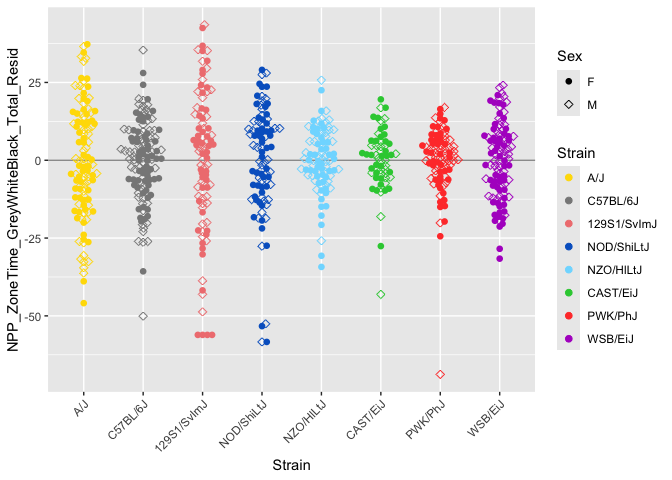

```r
NPP_resid = NPP_data
NPP_resid$NPP_ZoneTime_GreyWhiteBlack_Total_Resid = resid(lm(NPP_ZoneTime_GreyWhiteBlack_Total ~ Strain, data = NPP_resid))
NPP_resid$Strain = factor(NPP_resid$Strain,
                         levels = founders_key$strain,
                         ordered = TRUE)

ggplot(data = NPP_resid, aes(x = Strain, y = NPP_ZoneTime_GreyWhiteBlack_Total_Resid, color = Strain, shape = Sex)) +
  geom_hline(yintercept = 0, col = "#999999") +
  geom_beeswarm(size = 2) +
  scale_color_manual(values = founders_key$collaborative_cross_color_broman) +
  theme(axis.text.x = element_text(angle = 45, hjust = 1)) +
  scale_shape_manual(values = c(16,23))
```

These residuals appear to be good. Running the ANOVA for this model.

```r
anova(lm(NPP_ZoneTime_GreyWhiteBlack_Total ~ Strain, data = NPP_data))
```

|  | Df | Sum Sq | Mean Sq | F value | Pr(>F) |
| --- | --- | --- | --- | --- | --- |
| Strain | 7 | 30259.37 | 4322.7666 | 18.38702 | 1.08321e-22 |
| Residuals | 759 | 178440.04 | 235.0989 | NA | NA |

```r
anova(lm(NPP_ZoneTime_GreyWhiteBlack_Total ~ Strain, data = NPP_data))$`Pr(>F)`[1]
```

```
## [1] 1.08321e-22
```

### 2.3.11 Calculating heritability for novel place preference data

Calculating heritability using the ANOVA table from the best fitting model. Using the following equation:

$h^2=\displaystyle{{MS_{strain}-MS_{resid}}\over{MS_{strain} + (n_{mean} - 1) * MS_{resid}}}$

where $MS_{strain}$ is the mean square of the strain differences, $MS_{resid}$ is the mean square of the residuals, and $n_{mean}$ is the mean sample size of a strain.

```r
mean_n = nrow(NPP_data) / length(unique(NPP_data$Strain))
anova_NPP = anova(lm(NPP_ZoneTime_GreyWhiteBlack_Total ~ Strain, data = NPP_data))
anova_NPP_df = as.data.frame(anova_NPP)
h2_NPP = h2_strainanova(anova_NPP_df["Strain","Mean Sq"],
                        anova_NPP_df["Residuals","Mean Sq"],
                        mean_n)
h2_NPP
```

```
## [1] 0.1535114
```

This $H^2$ calculation of 0.15 is worse than previous estimates, which were above 0.2.

### 2.3.12 Plotting strain x sex means for novel place preference

Plotting the strain:sex information for these data.

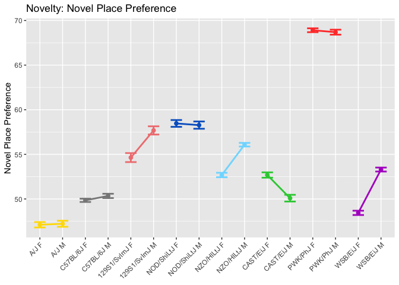

```r
NPP_plotting_summary = NPP_data %>%
  group_by(Strain, Sex) %>%
  summarize(Strain_Sex_mean = mean(NPP_ZoneTime_GreyWhiteBlack_Total, na.rm = TRUE),
            Strain_Sex_sem = sd(NPP_ZoneTime_GreyWhiteBlack_Total, na.rm = TRUE) / length(which(!is.na(NPP_ZoneTime_GreyWhiteBlack_Total)))) %>%
  mutate(Strain_Sex = paste(Strain, gsub("^([MF]).*$", "\\1", Sex), sep = " "),
         Strain_Sex_ul = Strain_Sex_mean + Strain_Sex_sem,
         Strain_Sex_ll = Strain_Sex_mean - Strain_Sex_sem)
NPP_plotting_summary = as.data.frame(NPP_plotting_summary)
NPP_plotting_summary$Strain_Sex = factor(NPP_plotting_summary$Strain_Sex,
                                         levels = paste(rep(founders_key$strain, each = 2), rep(c(" F", " M"), times = 8), sep = ""),
                                         ordered = TRUE)
NPP_plotting_summary$Strain = factor(NPP_plotting_summary$Strain,
                                     levels = founders_key$strain,
                                     ordered = TRUE)

NPP_preference_sex_plot = ggplot(data = NPP_plotting_summary, aes(x = Strain_Sex, y = Strain_Sex_mean, color = Strain, group = Strain)) +
  geom_line(size = 1) +
  geom_point(size = 2) +
  geom_errorbar(aes(ymin = Strain_Sex_ll, ymax = Strain_Sex_ul), width = 0.5, size = 1) +
  scale_color_manual(values = founders_key$collaborative_cross_color_broman) +
  theme(axis.text.x = element_text(angle = 45, hjust = 1), legend.position="none") +
  xlab(NULL) +
  ylab("Novel Place Preference") +
  ggtitle("Novelty: Novel Place Preference")

NPP_preference_sex_plot
```

Saving plot.

```r
saveRDS(NPP_preference_sex_plot, "./output/founders_NPP_preference_strain_sex_plot.RDS")
```

The PWK strain has the very interesting phenotype here.

# 3 Reproducibility Information

## 3.1 Software Used

### 3.1.1 R session and OS information

```r
novelty_heritability_sessionInfo
```

```r
saveRDS(novelty_heritability_sessionInfo, paste(script_root_dir, "./output/novelty_heritability_sessionInfo_",current_date,".RDS", sep = ""), compress="xz")
```

## 3.2 Document Control

This document was prepared using RMarkdown in RStudio.